# Building Linear Models

So far we have discussed fitting linear models in the context of models with one or two variables. In general, we have to fit models with potentially many variables, and some of them may act in a non-linear fashion. This note will discsuss how to fit models with many variables including non-linear models.

First we will examine how to assess the importance of factor variables. Since factors are composite variables, the statistical significance of a factor (main effect or interaction) cannot always be judged by examining the individual coefficients. One has to examine how well the model fits with and without the factor in the model. The smaller model (without the factor) is said to be *nested* inside the larger model (including the factor).

Next we will examine how to build non-linear models in situations where the relationship between the response and the predictor is non-linear, using polynomials or splines. Here also, we will use nested models: if we want to see if relationship is non-linear the first step is to check if a quadratic term improves fit. To do this, we compare nested models, with and without the quadratic term.

Finally, we will look at some of the linear algebra theory behind fitting linear models to better understand how linear models work. We make a semantic note here: the linear models framework has the capacity to fit *non-linear* models, by including non-linear terms in the linear model, such as a quadratic or cubic spline ters, or by including interactions between variables.

- Comparing nested models
- Building non-linearity
- Linear algebra behind linear models

## Datasets

First, let us introduce two datasets we will use.

### Flowering time dataset

We will use the flowering time dataset introduced before. It has some additional traits of interest in addition to flowering time: (a) rosette leaf number and (b) cauline leaf number. Essentially, the plant forms a rosette, and a stem. The leaves on the plant are of one or the other type. This is an example of a multi-factorial experiment.

```r
## set figure options)
options(repr.plot.width = 6, repr.plot.height = 6)
## load library
library(tidyverse)
vernURL <- "https://dryad-assetstore-merritt-west.s3.us-west-2.amazonaws.com/ark%3A/13030/m5bs3rq2%7C1%7Cproducer/Experiment1.txt?response-content-type=text%2Fplain&X-Amz-Security-Token=IQoJb3JpZ2luX2VjECMaCXVzLXdlc3QtMiJHMEUCIQD6Y1tjlnbdxXoxB981X0iQYSs82ilNlkNqS7iToZ8vkQIgUqqlS8o7Iseqw%2F9AWWt9uWs4fbg4PT7Lvpd1x%2FrjeVgq%2BgMIPBAAGgw0NTE4MjY5MTQxNTciDL1miuRKZfLt%2FzpNsirXA%2B6hRGKnBWqGX0GQ6yNWAk1NF5JSZw0pgPf%2BMfXCyV0kQVChduMk3HdNEdfFEmMbe44nFCwjBK1EBT6LngceXAUiA3n%2BpEJMiiWS5xUcpeTJ22m8X8y8czMtBbPZnr53dJdo69kuSaicB1qKqaRTrkw0VtYi7o2Fpb6EcLF7w28vbtWPTslxSNzDOMAfEnhCcVmk0BDhKNtQ5gDf%2Bl%2Bo%2FYzOXMn9aLA%2FkoKA6iOwvw%2FlK2h5ra0sAmQWRyON%2BRKUfcsJvITVEMFOt5A8rjX0MYYwnH26xCVS1PFArDB%2B3FxMINTuK5yjIOvK3FDJjMRBwehPwwMu5OGKKMu3MsejUmTzjl8a1QYsT9wphho1juPwTNp6zvQNdcuNOhnW4pi%2BgBtsAiZ3OnDqM2SKDxgLXw0lW7CuRGJWpaJpzcW%2FyOUzp8lUrn7i8AbNoGGZr4ToWvBEIsRAnZwm%2B5ROJIUlQfynJxVk%2FD1aUgmRQxV45RlD6%2FM%2FGSLckiW5rM8RPg84WSAFtcftkPKxdV57iG3E95OiU3WhQV1Us2ma9sq8y1jumvf3eZMdMNdYjIstRpvsyoozfhISaVH%2Bo7r%2Bhi1Y%2FfkHphESvZzkvy49hzdngpHV0JQ%2BbkhkZDDMgfmOBjqlARkMt9FttAc3NALXrg01RgyeVh3ykzSv65fd6S1%2FoTQVNE3y0SGW6mfQOM4SvDKoE%2F%2Fyv54us9pQ%2FKip8o8nMZugmChPgoOFxbGlcpL%2F0SQb50snG%2FscHwdWkWQNg58%2Boqa1bIkGYo6PqcTCfYM%2FELgm5Mijj6V5ZK%2FSE79nx3R7oyrs%2FC2%2FsAEw%2BB%2FNRaQzXQOvxWnQMciUbqsUSzh0ZXtUt5XZYA%3D%3D&X-Amz-Algorithm=AWS4-HMAC-SHA256&X-Amz-Date=20220112T033910Z&X-Amz-SignedHeaders=host&X-Amz-Expires=14400&X-Amz-Credential=ASIAWSMX3SNW56ARTNT5%2F20220112%2Fus-west-2%2Fs3%2Faws4_request&X-Amz-Signature=6bac424cce3b930399e9577f9856048cac80e781584060aeb87bbcf34cc58000"
tmpfile <- tempfile(fileext="txt")
download.file(vernURL,tmpfile)
vern <- read.table(tmpfile)
## select three columns of interest
vern <- select(vern,Genotype,Vernalization,Days.to.Flower,Rosette.leaf.num,Cauline.leaf.num)
## filter to only two genotypes of interest for three sets of genotypes
vern3 <- filter(vern,(Genotype=="Col Ama")|(Genotype=="Col FRI"))
vern2 <- filter(vern,(Genotype=="vin3-4")|(Genotype=="vin3-4 FRI"))
vern1 <- filter(vern,(Genotype=="hua2-3")|(Genotype=="hua2-3 FRI"))
## convert genotype to two-level factor
vern1$Genotype <- factor(as.character(vern1$Genotype))
vern2$Genotype <- factor(as.character(vern2$Genotype))
vern3$Genotype <- factor(as.character(vern3$Genotype))
head(vern1)
```

```
##      Genotype Vernalization Days.to.Flower Rosette.leaf.num Cauline.leaf.num
## 1681   hua2-3            NV             37               11                3
## 1682   hua2-3            NV             41                8                2
## 1683   hua2-3            NV             38               10                3
## 1684   hua2-3            NV             38               10                3
## 1685   hua2-3            NV             40               10                3
## 1686   hua2-3            NV             41               11                4
```

### Tree ring dataset

We will use data from [Bigler et. al. 2016](https://doi.org/10.1890/15-1402.1) who collected [tree ring data](https://doi.org/10.5061/dryad.1bv6n) from three datasets. The main data file has the width of tree rings for each tree in each year, as well as a metadata file with information about each tree (age, whether it is alive, species, and location). Three long-lived tree species were studied: *Abies alba* (silver fir), *Nothofagus dombeyi* (coihui), and *Quercus petraea* (sessile oak). This is an example of a longitudinal observational study.

```r
## two URLs
ringURL <- "https://dryad-assetstore-merritt-west.s3.us-west-2.amazonaws.com/ark%3A/13030/m5h46r0s%7C1%7Cproducer/RWdata.txt?response-content-type=text%2Fplain&X-Amz-Security-Token=IQoJb3JpZ2luX2VjECUaCXVzLXdlc3QtMiJHMEUCIQDPhUABCT5HpSWY2IEBqEpiqr%2BlJ1%2FLF6NGTuZsrmFqqgIgBiOwau8SRoLaYCi5aUO%2F4L7dizyiLUB6UB%2BEt8fe9TEq%2BgMIPhAAGgw0NTE4MjY5MTQxNTciDM0%2FJNrQ156%2BTRoMOCrXA68bdZc66Hk57OE9cuwfXyCkg9nNk4HzmKn5kYUE2krD%2BPmpeFhjTPenc1zzfXwhwEq8K1%2BbZU0qEJwqltTOKV7FYr8%2FWqklGFAM%2BlrtheRLCu8rELOqevdZH0N0uxyV8%2B04t4ooqmEYZBM6ExQLzYtndxJozN0NJ96IJBfOtFawnjkov4bWHd9Qdi1IU8%2BGUVcVpmNgcVEB6l6DoL5iNl2xk96RRiUQh%2FKhYyq02MmPVVHRkU4yA2UF5GWnloi%2FGG%2BRWwBsH%2FYK72UQXEr5LHnwoHHXMulSnZFmxX26NZljYYz%2BPcYr0R2JxhPuJ1ma5j79owO%2FFxKeSoN0nMyxatyh84it2jLTsrKYXjf1sTFU%2BFI%2Bgz2hmq8BhYwRVFLb7s3faKCjHiXmfjvZsErTy7qbWIyygXySzRcd5WsPAdmMt48jl%2BTewPgyLk6wbT0z8VLDFDYiYYPadHA9BCXLBFIxltlEIovavQjUmtCVOT0yUCNkagnBrv6u50sMyOcWgXYZ%2BSTs3Ct8nR9SmFGKdzi5q9%2F4nYb16uCBevk9h8Y5zoBQtSR7nWC9qHpfQwaeEVqKgIe7D5bg3TyUsO5tOGoxo064tDDQ9FhdwDAHlLHSgggygILFkzCFtfmOBjqlAZvxa75M9ZdwtYypSGwa2wBvprSa66sWV1fqVc%2Fzv57hIwKZ6M4B%2FyXC87xtMEoJNTwj1KXuCVEZEK3GADEedf49Ub4M2nq1QtwhTh4XMzVc3vES9T56Di7xQP%2F2ICQiNu9WY8PgNc95%2BjJ%2FN8s38gVwP%2F7Qn6hTUdMOe4u40UtT1vNJMamb4Dvjdbe408lkrkt9rnJutpi3maQIRjH4sJRI5fPShA%3D%3D&X-Amz-Algorithm=AWS4-HMAC-SHA256&X-Amz-Date=20220112T053959Z&X-Amz-SignedHeaders=host&X-Amz-Expires=14400&X-Amz-Credential=ASIAWSMX3SNWVGHV2UAT%2F20220112%2Fus-west-2%2Fs3%2Faws4_request&X-Amz-Signature=c62ea5e7dc19c1e65b0b5d172da300d8d2bfd14a608948991144c1b947eb4593"
ringmetaURL <- "https://dryad-assetstore-merritt-west.s3.us-west-2.amazonaws.com/ark%3A/13030/m5h46r0s%7C1%7Cproducer/Treedata.txt?response-content-type=text%2Fplain&X-Amz-Security-Token=IQoJb3JpZ2luX2VjECUaCXVzLXdlc3QtMiJHMEUCIApICQ5e4orpaUz6V90V84y4rKQGas8hu8Z4%2FMhVrkQvAiEAtypXDYHkius65tuIN5HysaeyXrLWTso%2BGISVpLtAimoq%2BgMIPhAAGgw0NTE4MjY5MTQxNTciDHenNr0G3dbPs1iiNirXAyzlctbdLA0jhf5nx%2F%2F3VCaND7a5KDqCtAG78TdPD%2Fyp8Ug4KIBcaGWefeIvDVsGibGWzqkgQuFXqz8YMurlvQYB1xpkHV2PzNes0hkfBHShSQQlxcdgBJ2OgJv3k4IqV84pHKjMIKwZ52OP1%2FWPaVltZlBe%2B8fey2tsCKOSgutUP96hLeoLrozBT2A5Qo5glI8wXoQZB3IWAct%2BhBaXOCR4VmmBkbXLzVoAqg2krtK3fY7JuClOwEZM64RBNJnq7uHY2sZg6LAMk6WES0CRW917U1fd0snRGZZCIy6Gjzp8Y2CcUEEKLpe9TYdeJDWUBno7qoBQOE9TxiJ%2FjMw4CUJGoyDteY7Z9h8yztvtX5uh0Vg%2BKzkUuOm47z77FqrgiIcr6gwezwEB%2FeIcqIa4ncpbHxamYRo7Q%2FDIwpQ0hsImux8t2ehzmsoxKaCtzLh5p33wQS3fYI3epi87XSwhcCXTiGoji%2FedeOwci8pAt5eJF9gP39Qd7havavlpInNg0%2FpgfprXGTPt4Udttm5Uji1a2HuWPgrmp3BNyElkZUy9Yf9GxczOeLU%2BPyXfUUbFz8z3A6y%2FpOVdN96JNZA4ZT%2F%2Bt0NpSobtDHARiKJazMAIq3%2Bth7rrujDVuvmOBjqlAXxCc1EnHqJihLjQo59NuwLVPoyY5ay383SfX0GY3fc%2FhLdjaQETFL8y6w3Rpo4ZPl2DS1o%2B0k84%2F4hPPzH1setTKmH4ttPoCJk2q48pXStSRQKmY1gN5o4lE64wNbVvn03bKuOY3ThfseRSEXwS3ZhV6km%2BGCF1FW00iDv%2FqYDDRzg%2BORQ50O68mwcLBfffqgeMb%2BFavNpnCNeUB%2BTFLjemO7xjmQ%3D%3D&X-Amz-Algorithm=AWS4-HMAC-SHA256&X-Amz-Date=20220112T054015Z&X-Amz-SignedHeaders=host&X-Amz-Expires=14400&X-Amz-Credential=ASIAWSMX3SNW2AJY2ZHN%2F20220112%2Fus-west-2%2Fs3%2Faws4_request&X-Amz-Signature=6bdcc3f90ec6c662856e48e7d285741a02ca023479b0699100fc34efd5aa0cd0"
## read in data
tmpfile <- tempfile(fileext="txt")
download.file(ringURL,tmpfile)
ring <- read.delim(tmpfile)
download.file(ringmetaURL,tmpfile)
ringmeta <- read.delim(tmpfile)
library(DT)
datatable(head(ring))
```

|  | Year | BIS84003 | BIS84004 | BIS84006 | BIS84007 | BIS84009 | BIS84010 | BIS84016 | BIS84019 | BIS84021 | BIS84022 | BIS84023 | BIS8603 | BIS89038 | BIS89039 | BIS89127 | BIS89144 | BIS89147 | BIS89160 | BIS89161 | RAV94003 | RAV94016 | RAV94018 | RAV94026 | RAV94030 | RAV94033 | RAV94050 | RAV94060 | RAV94065 | … |
| --- | --- | --- | --- | --- | --- | --- | --- | --- | --- | --- | --- | --- | --- | --- | --- | --- | --- | --- | --- | --- | --- | --- | --- | --- | --- | --- | --- | --- | --- | --- |
| 1 | 1793 |  |  |  |  |  |  |  |  |  |  |  |  |  |  |  |  |  |  |  |  |  |  |  |  |  |  |  |  | … |
| 2 | 1794 |  |  |  |  |  |  |  |  |  |  |  |  |  |  |  |  |  |  |  |  |  |  |  |  |  |  |  |  | … |
| 3 | 1795 |  |  |  |  |  |  |  |  |  |  |  |  |  |  |  |  |  |  |  |  |  |  |  |  |  |  |  |  | … |
| 4 | 1796 |  |  |  |  |  |  |  |  |  |  |  |  |  |  |  |  |  |  |  |  |  |  |  |  |  |  |  |  | … |
| 5 | 1797 |  |  |  |  |  |  |  |  |  |  |  |  |  |  |  |  |  |  |  |  |  |  |  |  |  |  |  |  | … |
| 6 | 1798 |  |  |  |  |  |  |  |  |  |  |  |  |  |  |  |  |  |  |  |  |  |  |  |  |  |  |  |  | … |

```r
datatable(head(ringmeta))
```

|  | tree | site | species | article | contact | status | age | DBH |
| --- | --- | --- | --- | --- | --- | --- | --- | --- |
| 1 | BIS84003 | Bistra | Abies_alba | Bigler_et_al._2004 | Cufar_K | LIVING | 154 | 46.932 |
| 2 | BIS84004 | Bistra | Abies_alba | Bigler_et_al._2004 | Cufar_K | LIVING | 113 | 36.994 |
| 3 | BIS84006 | Bistra | Abies_alba | Bigler_et_al._2004 | Cufar_K | LIVING | 129 | 45.332 |
| 4 | BIS84007 | Bistra | Abies_alba | Bigler_et_al._2004 | Cufar_K | LIVING | 158 | 52.522 |
| 5 | BIS84009 | Bistra | Abies_alba | Bigler_et_al._2004 | Cufar_K | LIVING | 148 | 39.54 |
| 6 | BIS84010 | Bistra | Abies_alba | Bigler_et_al._2004 | Cufar_K | LIVING | 147 | 41.034 |

## Comparing nested models

Two models are said to be *nested* if the terms of a model are a subset of the other. It is possible to compare nested models using a likelihood ratio test (a generalization of ANOVA). Let us take a look at a few examples with the flowering time data. In the first example we want to examine if the interaction term between vernalization and genotype. Is it different from zero? What is the strength of evidence?

We can fit the model and look at the interaction term coefficient directly. The evidence that it is different from 0 is weak (p-value 0.56).

```r
out1 <- lm(Days.to.Flower~Genotype*Vernalization,data=vern1)
summary(out1)
```

```
##
## Call:
## lm(formula = Days.to.Flower ~ Genotype * Vernalization, data = vern1)
##
## Residuals:
##     Min      1Q  Median      3Q     Max
## -39.323 -18.463  -0.382  12.971  58.677
##
## Coefficients:
##                                   Estimate Std. Error t value Pr(>|t|)
## (Intercept)                         54.029      2.809  19.236   <2e-16 ***
## Genotypehua2-3 FRI                   9.294      4.018   2.313   0.0215 *
## VernalizationV                      -8.104      3.987  -2.033   0.0431 *
## Genotypehua2-3 FRI:VernalizationV   -3.337      5.660  -0.589   0.5560
## ---
## Signif. codes:  0 '***' 0.001 '**' 0.01 '*' 0.05 '.' 0.1 ' ' 1
##
## Residual standard error: 23.16 on 264 degrees of freedom
##   (2 observations deleted due to missingness)
## Multiple R-squared:  0.0678, Adjusted R-squared:  0.05721
## F-statistic: 6.401 on 3 and 264 DF,  p-value: 0.0003354
```

If we perform an ANOVA for that model we get the following table. Note that here, the order in which the terms appear, matters.

```r
anova(out1)
```

```
## Analysis of Variance Table
##
## Response: Days.to.Flower
##                         Df Sum Sq Mean Sq F value    Pr(>F)
## Genotype                 1   3735  3734.7  6.9617 0.0088221 **
## Vernalization            1   6380  6379.9 11.8924 0.0006559 ***
## Genotype:Vernalization   1    186   186.4  0.3475 0.5560366
## Residuals              264 141628   536.5
## ---
## Signif. codes:  0 '***' 0.001 '**' 0.01 '*' 0.05 '.' 0.1 ' ' 1
```

```r
anova(lm(Days.to.Flower~Vernalization*Genotype,data=vern1))
```

```
## Analysis of Variance Table
##
## Response: Days.to.Flower
##                         Df Sum Sq Mean Sq F value   Pr(>F)
## Vernalization            1   6233  6233.0 11.6186 0.000755 ***
## Genotype                 1   3882  3881.6  7.2354 0.007604 **
## Vernalization:Genotype   1    186   186.4  0.3475 0.556037
## Residuals              264 141628   536.5
## ---
## Signif. codes:  0 '***' 0.001 '**' 0.01 '*' 0.05 '.' 0.1 ' ' 1
```

We can also explicitly compare the model with only main effects with the model with an interaction term as follows. Here is the model with only the main effects.

```r
out2 <- lm(Days.to.Flower~Genotype+Vernalization,data=vern1)
summary(out2)
```

```
##
## Call:
## lm(formula = Days.to.Flower ~ Genotype + Vernalization, data = vern1)
##
## Residuals:
##     Min      1Q  Median      3Q     Max
## -38.464 -18.004  -0.398  12.606  59.536
##
## Coefficients:
##                    Estimate Std. Error t value Pr(>|t|)
## (Intercept)          54.851      2.436  22.521  < 2e-16 ***
## Genotypehua2-3 FRI    7.612      2.827   2.693 0.007529 **
## VernalizationV       -9.760      2.827  -3.453 0.000646 ***
## ---
## Signif. codes:  0 '***' 0.001 '**' 0.01 '*' 0.05 '.' 0.1 ' ' 1
##
## Residual standard error: 23.13 on 265 degrees of freedom
##   (2 observations deleted due to missingness)
## Multiple R-squared:  0.06657,    Adjusted R-squared:  0.05953
## F-statistic:  9.45 on 2 and 265 DF,  p-value: 0.0001085
```

Using an ANOVA (likelihood ratio test) comparing the two models we get the same answer.

```r
anova(out2,out1)
```

```
## Analysis of Variance Table
##
## Model 1: Days.to.Flower ~ Genotype + Vernalization
## Model 2: Days.to.Flower ~ Genotype * Vernalization
##   Res.Df    RSS Df Sum of Sq      F Pr(>F)
## 1    265 141814
## 2    264 141628  1    186.42 0.3475  0.556
```

The likelihood ratio tests are a better option when a factor has more than two levels (or if we want to evaluate the effect of a group of variables). Let us construct a dataset with all three of the backgrounnd genotypes put together.

We want to see if the effect of vernalization depends on genotype, across the six genotypes. The pattern is not very clear if we look at the individual coefficients.

```r
vern0 <- rbind(vern1,vern2,vern3)
out2 <- lm(Days.to.Flower~Genotype*Vernalization,data=vern0)
summary(out2)
```

```
##
## Call:
## lm(formula = Days.to.Flower ~ Genotype * Vernalization, data = vern0)
##
## Residuals:
##     Min      1Q  Median      3Q     Max
## -56.784 -22.229  -6.784  21.023  83.216
##
## Coefficients:
##                                   Estimate Std. Error t value Pr(>|t|)
## (Intercept)                         54.029      3.319  16.281  < 2e-16 ***
## Genotypehua2-3 FRI                   9.294      4.747   1.958  0.05063 .
## Genotypevin3-4                       8.801      4.747   1.854  0.06412 .
## Genotypevin3-4 FRI                  44.755      5.069   8.829  < 2e-16 ***
## GenotypeCol Ama                      6.486      4.729   1.372  0.17060
## GenotypeCol FRI                     31.855      5.041   6.319 4.54e-10 ***
## VernalizationV                      -8.104      4.711  -1.720  0.08578 .
## Genotypehua2-3 FRI:VernalizationV   -3.337      6.688  -0.499  0.61797
## Genotypevin3-4:VernalizationV        2.038      6.688   0.305  0.76065
## Genotypevin3-4 FRI:VernalizationV    1.748      7.222   0.242  0.80879
## GenotypeCol Ama:VernalizationV      -1.132      6.675  -0.170  0.86541
## GenotypeCol FRI:VernalizationV     -19.589      6.900  -2.839  0.00465 **
## ---
## Signif. codes:  0 '***' 0.001 '**' 0.01 '*' 0.05 '.' 0.1 ' ' 1
##
## Residual standard error: 27.37 on 743 degrees of freedom
##   (34 observations deleted due to missingness)
## Multiple R-squared:  0.2468, Adjusted R-squared:  0.2356
## F-statistic: 22.13 on 11 and 743 DF,  p-value: < 2.2e-16
```

The ANOVA will provide us with a single (omnibus) test for all the interaction terms together.

```r
anova(out2)
```

```
## Analysis of Variance Table
##
## Response: Days.to.Flower
##                         Df Sum Sq Mean Sq F value    Pr(>F)
## Genotype                 5 148025 29605.1 39.5325 < 2.2e-16 ***
## Vernalization            1  24327 24326.9 32.4843 1.733e-08 ***
## Genotype:Vernalization   5   9927  1985.5  2.6513   0.02187 *
## Residuals              743 556418   748.9
## ---
## Signif. codes:  0 '***' 0.001 '**' 0.01 '*' 0.05 '.' 0.1 ' ' 1
```

Using ANOVA, we can test the group of five interactions together.

## Two model formula tricks: the dot (.) and the I()

You can use the dot (`.`) operator to specify all terms in the data frame other than those already in the formula. For example, like this.

```r
lm(Days.to.Flower~.,data=vern1) %>% summary
```

```
##
## Call:
## lm(formula = Days.to.Flower ~ ., data = vern1)
##
## Residuals:
##      Min       1Q   Median       3Q      Max
## -23.0258  -5.3829  -0.1248   4.5648  26.6615
##
## Coefficients:
##                    Estimate Std. Error t value Pr(>|t|)
## (Intercept)        17.33122    1.23456  14.038  < 2e-16 ***
## Genotypehua2-3 FRI -2.27749    0.99004  -2.300   0.0222 *
## VernalizationV     -4.39143    0.97210  -4.517 9.47e-06 ***
## Rosette.leaf.num    1.84061    0.07516  24.490  < 2e-16 ***
## Cauline.leaf.num   -0.46925    0.31417  -1.494   0.1365
## ---
## Signif. codes:  0 '***' 0.001 '**' 0.01 '*' 0.05 '.' 0.1 ' ' 1
##
## Residual standard error: 7.87 on 262 degrees of freedom
##   (3 observations deleted due to missingness)
## Multiple R-squared:  0.8926, Adjusted R-squared:  0.8909
## F-statistic: 544.2 on 4 and 262 DF,  p-value: < 2.2e-16
```

To be fancier, you could try this. What does this do?

```r
lm(Days.to.Flower~.*.,data=vern1) %>% summary
```

```
##
## Call:
## lm(formula = Days.to.Flower ~ . * ., data = vern1)
##
## Residuals:
##      Min       1Q   Median       3Q      Max
## -17.1453  -5.5940  -0.3896   4.5385  25.1496
##
## Coefficients:
##                                     Estimate Std. Error t value Pr(>|t|)
## (Intercept)                         13.18392    2.33802   5.639 4.52e-08 ***
## Genotypehua2-3 FRI                  -3.22080    2.55994  -1.258  0.20948
## VernalizationV                      -6.28577    2.20245  -2.854  0.00467 **
## Rosette.leaf.num                     2.43616    0.17395  14.005  < 2e-16 ***
## Cauline.leaf.num                    -0.68749    0.73147  -0.940  0.34817
## Genotypehua2-3 FRI:VernalizationV    2.37746    1.98841   1.196  0.23293
## Genotypehua2-3 FRI:Rosette.leaf.num -0.33004    0.17523  -1.883  0.06078 .
## Genotypehua2-3 FRI:Cauline.leaf.num  1.23183    0.69074   1.783  0.07571 .
## VernalizationV:Rosette.leaf.num     -0.25347    0.17356  -1.460  0.14539
## VernalizationV:Cauline.leaf.num      1.00030    0.69465   1.440  0.15109
## Rosette.leaf.num:Cauline.leaf.num   -0.04302    0.01514  -2.842  0.00484 **
## ---
## Signif. codes:  0 '***' 0.001 '**' 0.01 '*' 0.05 '.' 0.1 ' ' 1
##
## Residual standard error: 7.687 on 256 degrees of freedom
##   (3 observations deleted due to missingness)
## Multiple R-squared:  0.8999, Adjusted R-squared:  0.8959
## F-statistic:   230 on 10 and 256 DF,  p-value: < 2.2e-16
```

The operators in model formulas have special meaning, but sometimes we mean them in an arithmetic sense. For example, we may want to construct a variable that is the total number of leaves. If we use it as follows, it does not do what we want. It is giving us two effects of cauline and rosette leaf numbers, but we want just one.

```r
lm(Days.to.Flower~Genotype+Vernalization+Rosette.leaf.num+Cauline.leaf.num,data=vern1) %>% summary
```

```
##
## Call:
## lm(formula = Days.to.Flower ~ Genotype + Vernalization + Rosette.leaf.num +
##     Cauline.leaf.num, data = vern1)
##
## Residuals:
##      Min       1Q   Median       3Q      Max
## -23.0258  -5.3829  -0.1248   4.5648  26.6615
##
## Coefficients:
##                    Estimate Std. Error t value Pr(>|t|)
## (Intercept)        17.33122    1.23456  14.038  < 2e-16 ***
## Genotypehua2-3 FRI -2.27749    0.99004  -2.300   0.0222 *
## VernalizationV     -4.39143    0.97210  -4.517 9.47e-06 ***
## Rosette.leaf.num    1.84061    0.07516  24.490  < 2e-16 ***
## Cauline.leaf.num   -0.46925    0.31417  -1.494   0.1365
## ---
## Signif. codes:  0 '***' 0.001 '**' 0.01 '*' 0.05 '.' 0.1 ' ' 1
##
## Residual standard error: 7.87 on 262 degrees of freedom
##   (3 observations deleted due to missingness)
## Multiple R-squared:  0.8926, Adjusted R-squared:  0.8909
## F-statistic: 544.2 on 4 and 262 DF,  p-value: < 2.2e-16
```

We can use the `I()` operator to isolate such expressions.

```r
lm(Days.to.Flower~Genotype+Vernalization+I(Rosette.leaf.num+Cauline.leaf.num),data=vern1) %>% summary
```

```
##
## Call:
## lm(formula = Days.to.Flower ~ Genotype + Vernalization + I(Rosette.leaf.num +
##     Cauline.leaf.num), data = vern1)
##
## Residuals:
##      Min       1Q   Median       3Q      Max
## -24.9526  -4.9246   0.1055   4.7265  26.4315
##
## Coefficients:
##                                        Estimate Std. Error t value Pr(>|t|)
## (Intercept)                            15.86733    1.29071  12.294  < 2e-16 ***
## Genotypehua2-3 FRI                     -2.03417    1.05453  -1.929   0.0548 .
## VernalizationV                         -4.64980    1.03527  -4.491 1.06e-05 ***
## I(Rosette.leaf.num + Cauline.leaf.num)  1.42829    0.03433  41.602  < 2e-16 ***
## ---
## Signif. codes:  0 '***' 0.001 '**' 0.01 '*' 0.05 '.' 0.1 ' ' 1
##
## Residual standard error: 8.389 on 263 degrees of freedom
##   (3 observations deleted due to missingness)
## Multiple R-squared:  0.8775, Adjusted R-squared:  0.8761
## F-statistic: 627.7 on 3 and 263 DF,  p-value: < 2.2e-16
```

## Building non-linear models

We now switch to the tree ring dataset. Here is a plot of the ring width of the ninth tree in that dataset. We can see that the dependence of ring width on year is highly non-linear. We can use linear models to build in non-linearity.

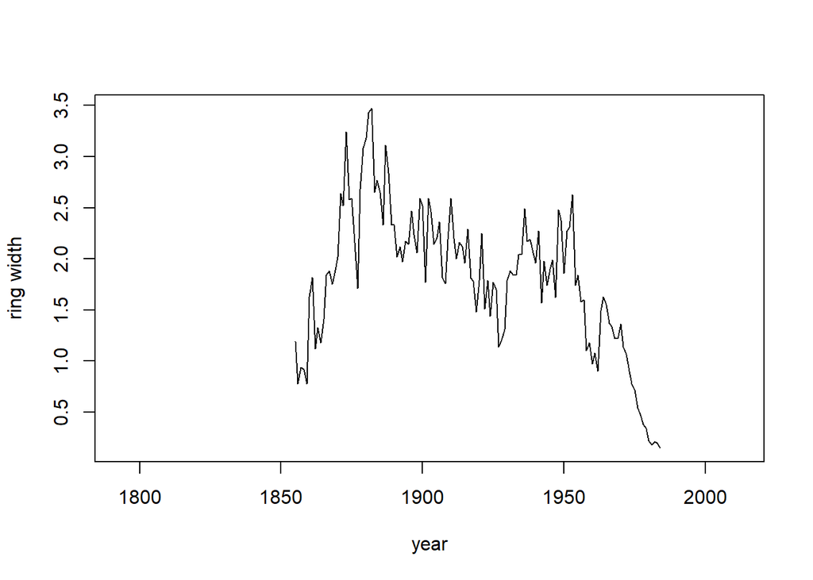

```r
plot(ring[,1],ring[,10],type="l",xlab="year",ylab="ring width")
```

Let us simplify things by just getting the data for that tree.

```r
year <- ring[,1]
ringwidth <- ring[,10]
idx <- complete.cases(cbind(year,ringwidth))
year <- year[idx]
ringwidth <- log(ringwidth[idx])
```

### Polynomials

One way to model non-linearity is to just add polynomial terms, beginning with the quadratic term. However, the obvious approach does not work.

```r
lm(ringwidth~year+year^2) %>% summary
```

```
##
## Call:
## lm(formula = ringwidth ~ year + year^2)
##
## Residuals:
##     Min      1Q  Median      3Q     Max
## -1.8403 -0.1326  0.1443  0.3181  0.7732
##
## Coefficients:
##              Estimate Std. Error t value Pr(>|t|)
## (Intercept) 15.982363   2.308935   6.922 1.92e-10 ***
## year        -0.008084   0.001203  -6.722 5.33e-10 ***
## ---
## Signif. codes:  0 '***' 0.001 '**' 0.01 '*' 0.05 '.' 0.1 ' ' 1
##
## Residual standard error: 0.5146 on 128 degrees of freedom
## Multiple R-squared:  0.2609, Adjusted R-squared:  0.2551
## F-statistic: 45.19 on 1 and 128 DF,  p-value: 5.333e-10
```

We have to use the `I` function here. The fit is better, but not good.

```r
rout1 <- lm(ringwidth~year+I(year^2))
summary(rout1)
```

```
##
## Call:
## lm(formula = ringwidth ~ year + I(year^2))
##
## Residuals:
##      Min       1Q   Median       3Q      Max
## -1.00791 -0.18820  0.00738  0.25416  0.68668
##
## Coefficients:
##               Estimate Std. Error t value Pr(>|t|)
## (Intercept) -1.098e+03  8.824e+01  -12.44   <2e-16 ***
## year         1.153e+00  9.196e-02   12.54   <2e-16 ***
## I(year^2)   -3.025e-04  2.395e-05  -12.63   <2e-16 ***
## ---
## Signif. codes:  0 '***' 0.001 '**' 0.01 '*' 0.05 '.' 0.1 ' ' 1
##
## Residual standard error: 0.344 on 127 degrees of freedom
## Multiple R-squared:  0.6723, Adjusted R-squared:  0.6671
## F-statistic: 130.3 on 2 and 127 DF,  p-value: < 2.2e-16
```

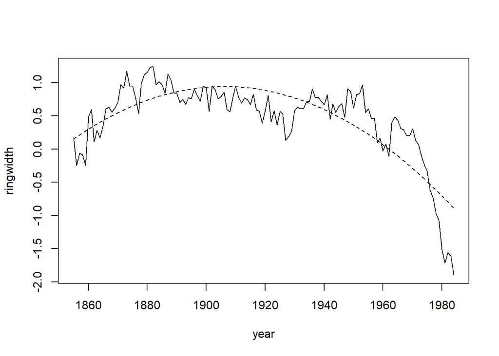

```r
plot(year,ringwidth,type="l")
lines(year,predict(rout1),lty=2)
```

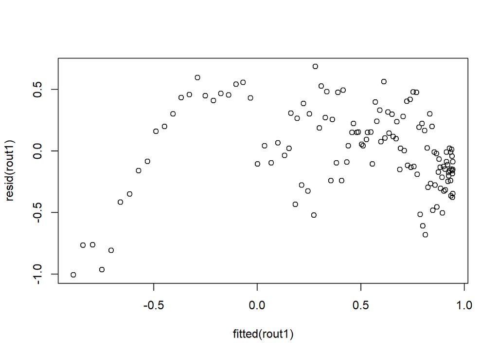

```r
plot(fitted(rout1),resid(rout1))
```

To improve, we can use a cubic term, which improves fit, but still is not good.

```r
rout2 <- lm(ringwidth~year+I(year^2)+I(year^3))
summary(rout2)
```

```
##
## Call:
## lm(formula = ringwidth ~ year + I(year^2) + I(year^3))
##
## Residuals:
##      Min       1Q   Median       3Q      Max
## -0.79495 -0.19956 -0.01405  0.24626  0.60128
##
## Coefficients:
##               Estimate Std. Error t value Pr(>|t|)
## (Intercept)  1.449e+04  4.968e+03   2.916  0.00419 **
## year        -2.322e+01  7.768e+00  -2.989  0.00336 **
## I(year^2)    1.240e-02  4.048e-03   3.063  0.00268 **
## I(year^3)   -2.205e-06  7.029e-07  -3.138  0.00212 **
## ---
## Signif. codes:  0 '***' 0.001 '**' 0.01 '*' 0.05 '.' 0.1 ' ' 1
##
## Residual standard error: 0.3326 on 126 degrees of freedom
## Multiple R-squared:  0.6961, Adjusted R-squared:  0.6888
## F-statistic: 96.18 on 3 and 126 DF,  p-value: < 2.2e-16
```

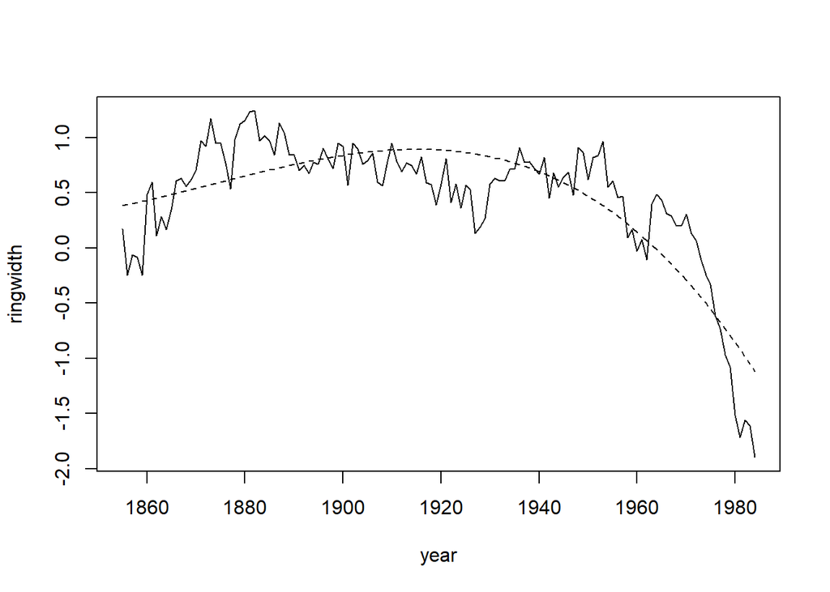

```r
plot(year,ringwidth,type="l")
lines(year,predict(rout2),lty=2)
```

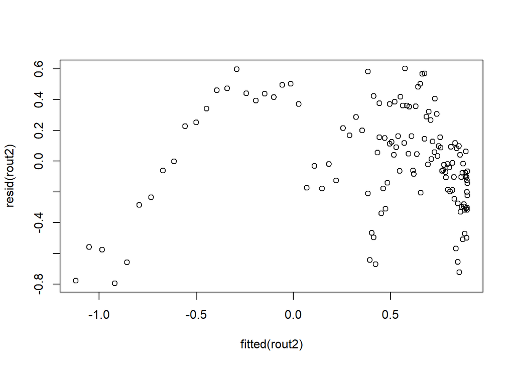

```r
plot(fitted(rout2),resid(rout2))
```

```r
rout3 <- lm(ringwidth~poly(year,10))
summary(rout3)
```

```
##
## Call:
## lm(formula = ringwidth ~ poly(year, 10))
##
## Residuals:
##      Min       1Q   Median       3Q      Max
## -0.48169 -0.12867  0.01975  0.09632  0.48462
##
## Coefficients:
##                   Estimate Std. Error t value Pr(>|t|)
## (Intercept)       0.464624   0.016615  27.964  < 2e-16 ***
## poly(year, 10)1  -3.459011   0.189441 -18.259  < 2e-16 ***
## poly(year, 10)2  -4.343490   0.189441 -22.928  < 2e-16 ***
## poly(year, 10)3  -1.043651   0.189441  -5.509 2.12e-07 ***
## poly(year, 10)4  -2.981719   0.189441 -15.740  < 2e-16 ***
## poly(year, 10)5  -0.436605   0.189441  -2.305  0.02292 *
## poly(year, 10)6  -0.005366   0.189441  -0.028  0.97745
## poly(year, 10)7  -0.408268   0.189441  -2.155  0.03317 *
## poly(year, 10)8   0.077084   0.189441   0.407  0.68481
## poly(year, 10)9  -0.225309   0.189441  -1.189  0.23668
## poly(year, 10)10  0.602390   0.189441   3.180  0.00188 **
## ---
## Signif. codes:  0 '***' 0.001 '**' 0.01 '*' 0.05 '.' 0.1 ' ' 1
##
## Residual standard error: 0.1894 on 119 degrees of freedom
## Multiple R-squared:  0.9069, Adjusted R-squared:  0.899
## F-statistic: 115.9 on 10 and 119 DF,  p-value: < 2.2e-16
```

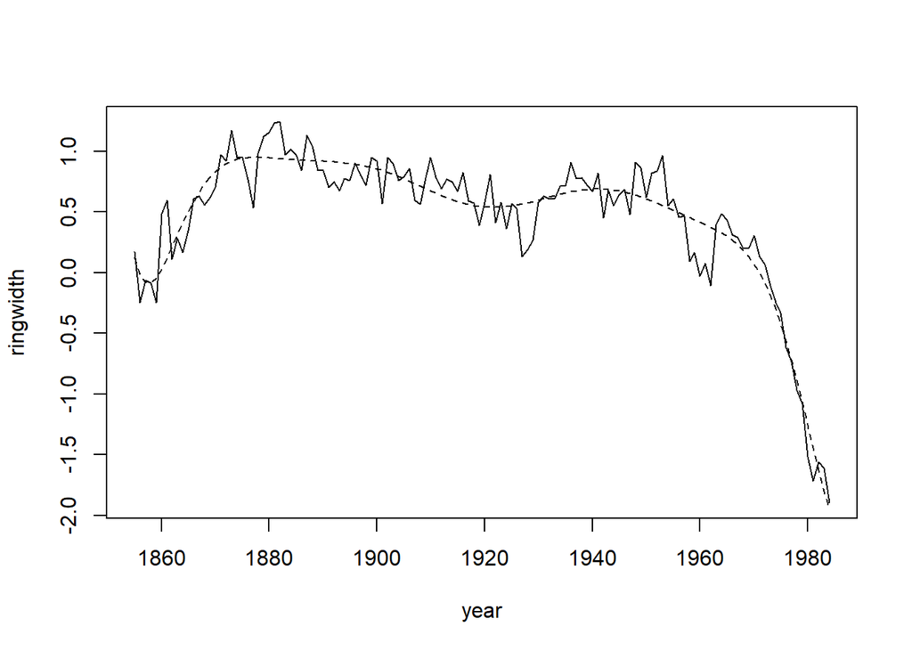

```r
plot(year,ringwidth,type="l")
lines(year,predict(rout3),lty=2)
```

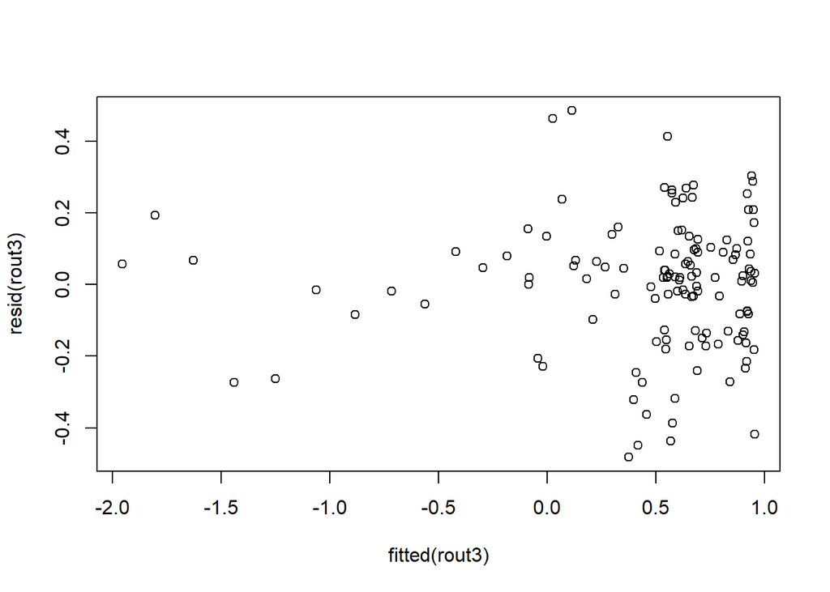

```r
plot(fitted(rout3),resid(rout3))
```

### Splines

Splines are another way to fit the models flexibly, and often fit non-linear data better than polynomials. Splines are piecewise polynomials that have smoothness constraints. They divide the range of the predictor into bins, and fit a polynomial (usually cubic) to each bin, with the constraint that polynomials in neighboring bins agree at the junction (called a knot), and the slope and curvature are also the same.

Below, we use B-splines with 12 degrees of freedom to fit the data. B-splines with $k$ internal knots will have $k+3$ degrees of freedom. The logic is as follows.

If we have $k$ knots, we are dividing the range of te variable into $k+1$ intervals. In each interval, we have a cubic polynomial, so we have to use $4(k+1)$ parameters.

However, we have constraints! Cubics in neighboring intervals need to have the same value, slope, and curvature at the common knot. Since there are $k$ knots, we have $3k$ constraints.

Therefore the degrees of freedom for the B-splines is $4k + 4 - 3k = k+4$. Since we usually will not consider the intercept, B-splines with $k$ knots have $k+3$ degrees of freedom.

```r
## load library
library(splines)
## fit b-splines with 12 df
rout4 <- lm(ringwidth~bs(year,df=12))
summary(rout4)
```

```
##
## Call:
## lm(formula = ringwidth ~ bs(year, df = 12))
##
## Residuals:
##      Min       1Q   Median       3Q      Max
## -0.48615 -0.09248  0.00508  0.10457  0.45807
##
## Coefficients:
##                     Estimate Std. Error t value Pr(>|t|)
## (Intercept)         -0.05154    0.13041  -0.395 0.693426
## bs(year, df = 12)1   0.04650    0.24946   0.186 0.852443
## bs(year, df = 12)2   0.77623    0.17141   4.529 1.44e-05 ***
## bs(year, df = 12)3   1.29484    0.19112   6.775 5.30e-10 ***
## bs(year, df = 12)4   0.69501    0.16441   4.227 4.71e-05 ***
## bs(year, df = 12)5   0.98859    0.17423   5.674 1.03e-07 ***
## bs(year, df = 12)6   0.55598    0.16789   3.312 0.001234 **
## bs(year, df = 12)7   0.44857    0.17148   2.616 0.010072 *
## bs(year, df = 12)8   1.15275    0.17130   6.729 6.65e-10 ***
## bs(year, df = 12)9   0.08990    0.17812   0.505 0.614716
## bs(year, df = 12)10  0.75939    0.20050   3.787 0.000242 ***
## bs(year, df = 12)11 -1.32904    0.20527  -6.475 2.32e-09 ***
## bs(year, df = 12)12 -1.84798    0.18438 -10.023  < 2e-16 ***
## ---
## Signif. codes:  0 '***' 0.001 '**' 0.01 '*' 0.05 '.' 0.1 ' ' 1
##
## Residual standard error: 0.1749 on 117 degrees of freedom
## Multiple R-squared:  0.922,  Adjusted R-squared:  0.914
## F-statistic: 115.2 on 12 and 117 DF,  p-value: < 2.2e-16
```

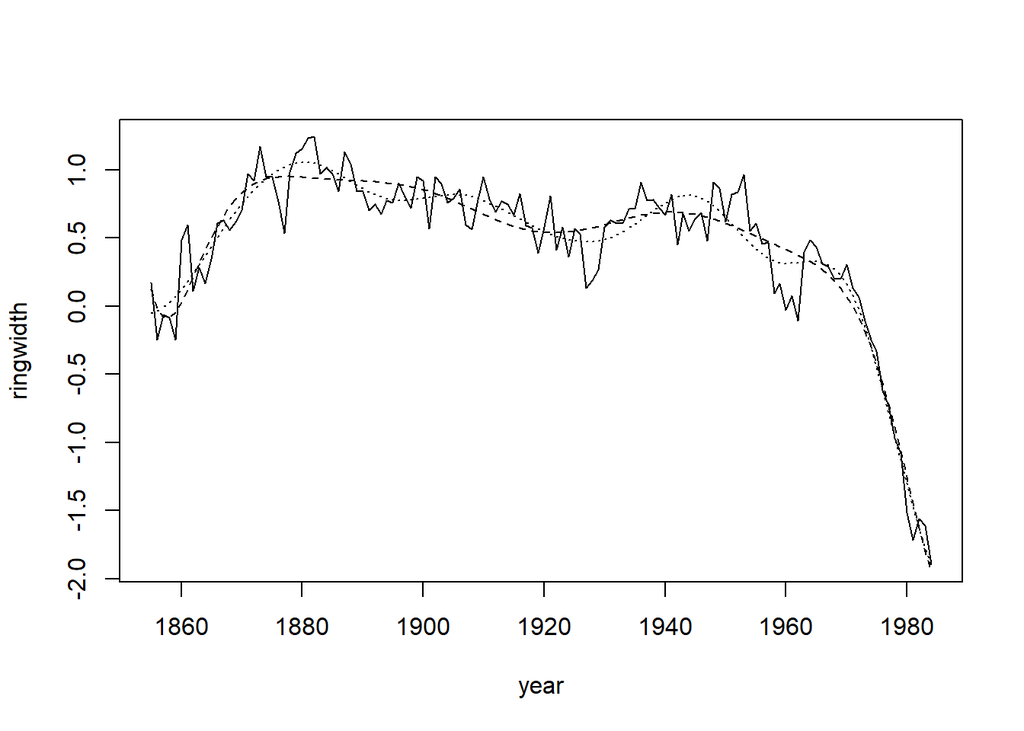

```r
plot(year,ringwidth,type="l")
lines(year,predict(rout4),lty=3)
lines(year,predict(rout3),lty=2)
```

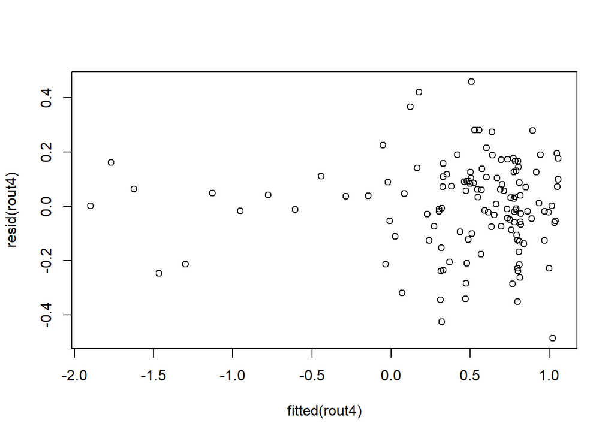

```r
plot(fitted(rout4),resid(rout4))
```

A variation on B-splines are natural splines. They are identical with B-splines except that they are linear at the edges – they usually fit better near the edge and do not show a “unnatural” curvature at the edges.

```r
## fit natural splines with 10 df
rout5 <- lm(ringwidth~ns(year,df=10))
summary(rout5)
```

```
##
## Call:
## lm(formula = ringwidth ~ ns(year, df = 10))
##
## Residuals:
##      Min       1Q   Median       3Q      Max
## -0.48144 -0.09430  0.01437  0.10278  0.43881
##
## Coefficients:
##                     Estimate Std. Error t value Pr(>|t|)
## (Intercept)         -0.13059    0.09144  -1.428 0.155875
## ns(year, df = 10)1   1.42305    0.12018  11.841  < 2e-16 ***
## ns(year, df = 10)2   0.74582    0.15187   4.911 2.92e-06 ***
## ns(year, df = 10)3   1.08718    0.13638   7.972 1.07e-12 ***
## ns(year, df = 10)4   0.61623    0.14502   4.249 4.29e-05 ***
## ns(year, df = 10)5   0.55333    0.14045   3.940 0.000138 ***
## ns(year, df = 10)6   1.18869    0.14270   8.330 1.60e-13 ***
## ns(year, df = 10)7   0.24821    0.14069   1.764 0.080257 .
## ns(year, df = 10)8   0.46655    0.11798   3.954 0.000131 ***
## ns(year, df = 10)9  -0.39832    0.23353  -1.706 0.090689 .
## ns(year, df = 10)10 -2.32731    0.10456 -22.258  < 2e-16 ***
## ---
## Signif. codes:  0 '***' 0.001 '**' 0.01 '*' 0.05 '.' 0.1 ' ' 1
##
## Residual standard error: 0.1754 on 119 degrees of freedom
## Multiple R-squared:  0.9202, Adjusted R-squared:  0.9135
## F-statistic: 137.2 on 10 and 119 DF,  p-value: < 2.2e-16
```

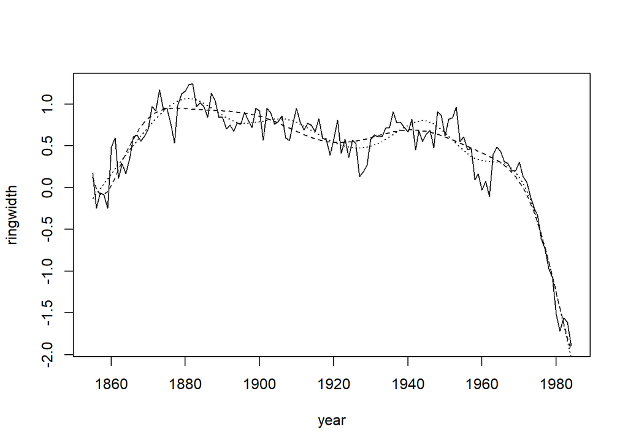

```r
plot(year,ringwidth,type="l")
lines(year,predict(rout5),lty=3)
lines(year,predict(rout3),lty=2)
```

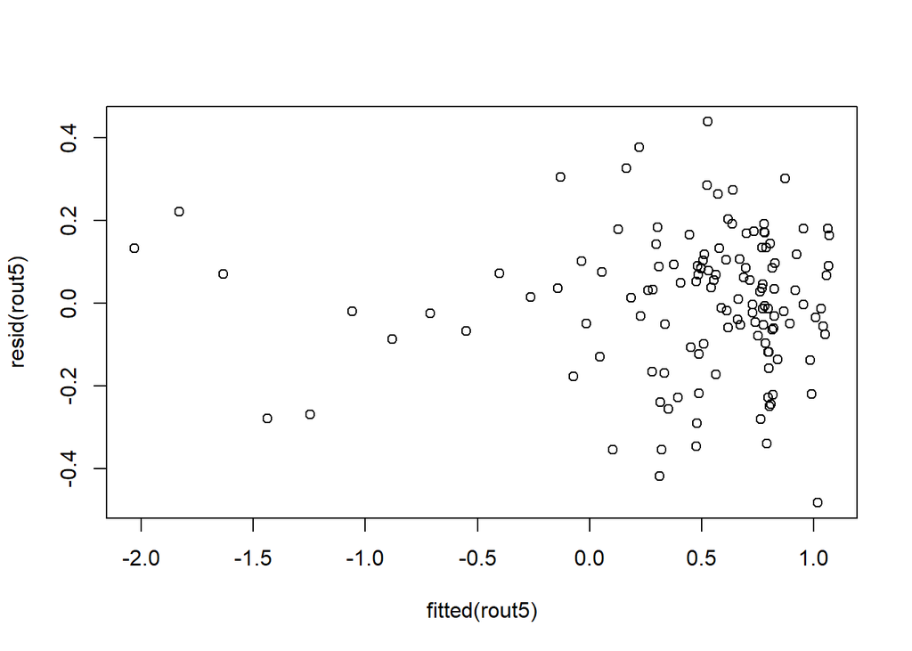

```r
plot(fitted(rout5),resid(rout5))
```

## Linear algebra behind linear models

Internally, all models are represented as numeric variables whether they are numeric, factors, polynomials or splines. The vector of response, is $y$, and the model formula is used to convert the predictors to a “design matrix” called $X$. The final model is of the form:

$$y = X\beta + \epsilon.$$

It can be shown that the least squares estimate is
$$\hat{\beta} = (X^{\prime}X)^{-1}X^{\prime}y.$$

Let us look at this for a simple case.

```r
out <- lm(Days.to.Flower~Genotype,data=vern1)
summary(out)
```

```
##
## Call:
## lm(formula = Days.to.Flower ~ Genotype, data = vern1)
##
## Residuals:
##     Min      1Q  Median      3Q     Max
## -36.474 -18.474  -2.974  15.993  64.526
##
## Coefficients:
##                    Estimate Std. Error t value Pr(>|t|)
## (Intercept)          50.007      2.031  24.617   <2e-16 ***
## Genotypehua2-3 FRI    7.466      2.884   2.589   0.0102 *
## ---
## Signif. codes:  0 '***' 0.001 '**' 0.01 '*' 0.05 '.' 0.1 ' ' 1
##
## Residual standard error: 23.6 on 266 degrees of freedom
##   (2 observations deleted due to missingness)
## Multiple R-squared:  0.02458,    Adjusted R-squared:  0.02092
## F-statistic: 6.704 on 1 and 266 DF,  p-value: 0.01015
```

We focus on the individuals with complete data, and subset the data. Then we extract the response variable $y$, and the design matrix using the command `model.matrix`.

```r
idx <- complete.cases(vern1$Days.to.Flower,vern1$Genotype)
vern1 <- vern1[idx,]
y <- vern1$Days.to.Flower
X <- model.matrix(out)
table(vern1$Genotype)
```

```
##
##     hua2-3 hua2-3 FRI
##        135        133
```

```r
(vern1[130:140,])
```

```
##        Genotype Vernalization Days.to.Flower Rosette.leaf.num Cauline.leaf.num
## 1811     hua2-3             V             50               22                5
## 1812     hua2-3             V             50               22                5
## 1813     hua2-3             V             48               23                6
## 1814     hua2-3             V             53               22                4
## 1815     hua2-3             V             51               22                5
## 1816     hua2-3             V             52               23                5
## 1817 hua2-3 FRI            NV             42               10                3
## 1818 hua2-3 FRI            NV             42               13                4
## 1819 hua2-3 FRI            NV             44               14                3
## 1820 hua2-3 FRI            NV             48               17                6
## 1821 hua2-3 FRI            NV             50               17                5
```

```r
(X[130:140,])
```

```
##      (Intercept) Genotypehua2-3 FRI
## 1811           1                  0
## 1812           1                  0
## 1813           1                  0
## 1814           1                  0
## 1815           1                  0
## 1816           1                  0
## 1817           1                  1
## 1818           1                  1
## 1819           1                  1
## 1820           1                  1
## 1821           1                  1
```

Let us now construct the matrix $X^\prime X$.

```r
## XtX matrix
XtX <-  t(X) %*% X
XtX
```

```
##                    (Intercept) Genotypehua2-3 FRI
## (Intercept)                268                133
## Genotypehua2-3 FRI         133                133
```

Now we calculate it’s inverse, $\left(X^{\prime}X\right)^{-1}$.

```r
## its inverse
XtXinv <- solve(XtX)
XtXinv
```

```
##                     (Intercept) Genotypehua2-3 FRI
## (Intercept)         0.007407407       -0.007407407
## Genotypehua2-3 FRI -0.007407407        0.014926204
```

And finally the least squares solution: $\hat{\beta} = (X^{\prime}X)^{-1}X^{\prime}y$

```r
## least squares solution
b <- XtXinv %*% t(X) %*% y
b
```

```
##                         [,1]
## (Intercept)        50.007407
## Genotypehua2-3 FRI  7.466277
```

We get exactly what `lm` returns to us.

```r
X %*% XtXinv %*% t(X)  %>% diag %>% sum
```

```
## [1] 2
```

The residual degrees of freedom is the trace of the matrix
$$I - X (X^{\prime}X)^{-1} X^{\prime}$$

```r
( diag(rep(1,nrow(X))) - X %*% XtXinv %*% t(X) ) %>% diag %>% sum
```

```
## [1] 266
```